# Ma-Cantine : Bilan statistique 2023

Author

Quentin Loridant

Published

May 24, 2023

# Introduction

## Contexte

Le bilan statistique annuel de l’application des objectifs d’approvisionnement fixés à la restauration collective donne lieu à un rapport du gouvernement qui est remis au parlement chaque année. Celui-ci contient une analyse des données de la campagne de télédéclaration. Le premier bilan est disponible pour la [campagne 2022](https://1648047458-files.gitbook.io/~/files/v0/b/gitbook-x-prod.appspot.com/o/spaces%2F-MSCF7Mdc8yfeIjMxMZr%2Fuploads%2F6RxGNr0aJ4BPSzFsDQGs%2FBilan%20statistique%20EGAlim_achats2021.pdf?alt=media&token=).

Dans ce document nous créeons et documentons les statistiques nécessaires pour la campagne 2023. Cette campagne a eu lieu sur le premier semestre 2023 et porte sur les données de l’année 2022.

## Changements par rapport à la campagne 2022

En 2021, l’application ne permettait pas de spécifier le mode de télédéclaration (cuisine centrale ou satellite). Pour la campagne 2023, il est possible que la télédéclaration soit rensignée soit par :

- une cuisine préparant ses propres repas
- une cuisine centrale (dans ce cas elle peut renseigner les données pour ces satellites)
- une cuisine satellite directement

Vous pouvez retrouver le code utilisé pour ces filtres ci dessous :

```python
def add_canteen_info(df):

    url = f"https://ma-cantine-metabase.cleverapps.io/api/card/820/query/json"
    res = requests.post(
        url,
        headers= {
        "Content-Type": "application/json",
        "X-Metabase-Session": os.environ.get('METABASE_TOKEN'),
    }
    )
    td_canteen = pd.DataFrame(res.json())

    col_to_rename={}
    for col in ['production_type', 'management_type', 'yearly_meal_count', 'daily_meal_count']:
        del df[f"canteen.{col}"]
        col_to_rename[f"{col}"] = f"canteen.{col}"
    td_canteen = td_canteen.rename(columns=col_to_rename)

    df = df.merge(right=td_canteen, left_on='canteen_id', right_on='id')
    return df
```

```python
td = td_raw.copy()
td = td[td.status == 'SUBMITTED']
td = td[td.canteen_id.notnull()]
tds = {}
for year in campagnes.keys():
    tds[year] = td.copy()
    tds[year] = tds[year][tds[year].year==int(year)]
    tds[year] = tds[year][(tds[year]['creation_date'] >= campagnes[year]["start_date"]) & (tds[year]['creation_date'] <= campagnes[year]["end_date"])]

tds['2021'] = add_canteen_info(tds['2021'])
```

# Comparaison de la dynamique de télédéclarations lors des deux dernières campagnes.

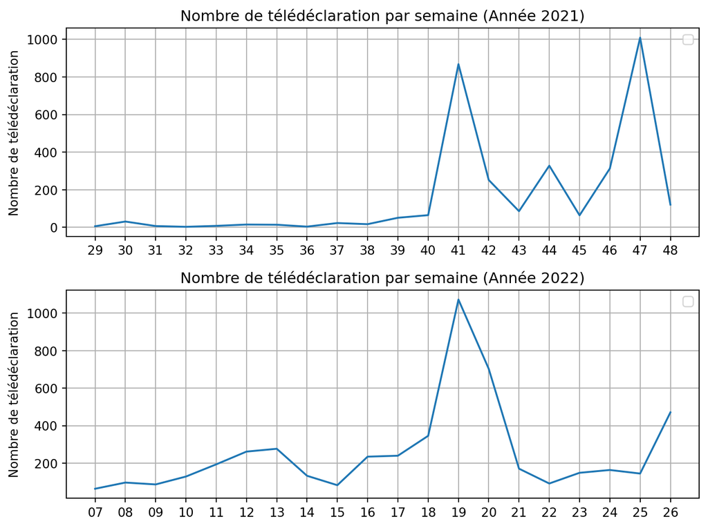

```python
tds_ts =  {}
for year in campagnes.keys():
    tds_ts[year] = tds[year].copy()
    tds_ts[year]['creation_date'] = pd.to_datetime(tds_ts[year]['creation_date']).dt.strftime('%V')
    tds_ts[year] = tds_ts[year].groupby('creation_date').count()
    tds_ts[year] = tds_ts[year].rename(columns={'canteen_id': 'cmpt_td_2022'})

import matplotlib.pyplot as plt
# Plot the superposed time series
axe = 0
fig, axes = plt.subplots(nrows=2, ncols=1, figsize=(8, 6))
for year in tds_ts.keys():

    axes[axe].plot(tds_ts[year].index, tds_ts[year]['cmpt_td_2022'])
    axes[axe].set_ylabel('Nombre de télédéclaration')
    axes[axe].set_title(f'Nombre de télédéclaration par semaine (Année {year})')
    axes[axe].legend()
    axes[axe].grid(True)
    axe += 1

plt.tight_layout()
plt.show()
```

# Traitement des valeurs manquantes

Nous remplaçons les valeurs manquantes par la valeur 0.

```python
for year in ['2021', '2022']:
    tds[year] = tds[year].fillna(0)
```

# Chiffres clés

Dans les télédéclarations pour la campagne 2022, il n’y a pas d’indication du nombre de satellites, du managment_type et du production_type.

Les informations suivantes proviennent donc des informations renseignées pour les cantines. Les données ont peut-être légérement été modifié depuis la télédéclaration.

```python
indicateurs = {}
for year in ['2021', '2022']:
    print(year)
    indicateurs[year] = {}
    indicateurs[year]["Nombre de Télédéclarations"] = len(tds[year])
    indicateurs[year]["Nombre de sites de restauration concernés par la télédéclaration"] = (
        len(tds[year]) + tds[year]["satellite_canteens_count"].sum()
    )
    cuisines_sur_place = tds[year][tds[year]["canteen.production_type"].isin(["site", "site_cooked_elsewhere"])]
    indicateurs[year]["Nombre de cantines sur place (sites et satellites)"] = len(cuisines_sur_place)

    cuisines_centrales = tds[year][tds[year]["canteen.production_type"].isin(["central_serving", "central"])]

    indicateurs[year]["Nombre de repas moyens par jour pour les cantines sur place"] = int(
        cuisines_sur_place["canteen.daily_meal_count"].mean()
    )
    indicateurs[year]["Nombre de repas moyens par jour pour les cantines centrales"] = int(
        cuisines_centrales["canteen.daily_meal_count"].mean()
    )
    indicateurs[year]["Nombre de repas totaux pour l'année"] = int(tds[year]["canteen.yearly_meal_count"].sum())

    indicateurs[year]["Répartition du nombre de cantines en gestion directe"] = f"{100 * len(tds[year][tds[year]['canteen.management_type'] == 'direct']) / len(tds[year]):.2f} %"
    indicateurs[year][
        "Répartition du nombre de cantines en gestion concédée"
    ] = f"{100 * len(tds[year][tds[year]['canteen.management_type'] == 'conceded']) / len(tds[year]):.2f} %"
    indicateurs[year][
        "Répartition du nombre de cantines en gestion non renseignée"
    ] = f"{100 * len(tds[year][~tds[year]['canteen.management_type'].isin(['direct', 'conceded'])]) / len(tds[year]):.2f} %"
```

```
2021
2022
```

Pour les montants, nous nous rebasons sur les données de TD.

```python
indicateurs["Montants d'achat alimentaires déclarés"] = f"{int(td['teledeclaration.value_total_ht'].sum())} €"

indicateurs[
    "Taux global des achats en bio"
] = f"{100 * td['teledeclaration.value_bio_ht'].sum() / td['teledeclaration.value_total_ht'].sum():.2f} %"

indicateurs[
    "Taux global des achats EGALIM (bio inclus)"
] = f"{100 * (td['teledeclaration.value_egalim_others_ht'].sum() + td['teledeclaration.value_externality_performance_ht'].sum() + td['teledeclaration.value_bio_ht'].sum()  + td['teledeclaration.value_sustainable_ht'].sum()) / td['teledeclaration.value_total_ht'].sum():.2f} %"

indicateurs['Nombre de TD ayant déclaré 0€ d\'achats en Bio'] = len(td[td['teledeclaration.value_bio_ht'] == 0])

for i in indicateurs:
    print(i, indicateurs[i])
```

```
2021 {'Nombre de Télédéclarations': 3285, 'Nombre de sites de restauration concernés par la télédéclaration': 3285.0, 'Nombre de cantines sur place (sites et satellites)': 2944, 'Nombre de repas moyens par jour pour les cantines sur place': 481, 'Nombre de repas moyens par jour pour les cantines cen…
2022 {'Nombre de Télédéclarations': 5114, 'Nombre de sites de restauration concernés par la télédéclaration': 10095.0, 'Nombre de cantines sur place (sites et satellites)': 4633, 'Nombre de repas moyens par jour pour les cantines sur place': 398, 'Nombre de repas moyens par jour pour les cantines ce…
Montants d'achat alimentaires déclarés 3348566925 €
Taux global des achats en bio 8.86 %
Taux global des achats EGALIM (bio inclus) 19.42 %
Nombre de TD ayant déclaré 0€ d'achats en Bio 178
```

```python
print(
    f"Le taux de présence de la donnée repas par an est de {100 * (1 - td['canteen.yearly_meal_count'].isna().sum() / len(td)):.2f} %"
)
```

```
Le taux de présence de la donnée repas par an est de 60.79 %
```

# Traitement des champs manquants, stratégie 2022

## Stratégie 2022

Si les 4 champs sont vides => on ne force pas à 0 (108 cantines concernés)

- Pour le calcul du bio -> mettre les valeurs à 0
- Pour le calcul du EGAlim -> mettre les valeurs à 0
- Pour les TD complètes de la campagne , on ne retrouvait pas les bonnes valeurs : total bio et somme des achats bio 22 TD complètes. Le total des achats bio est rempli automatiquement. Le calcul ne correspondait pas à la somme de tous les produits bio. Corrigé ?

## Stratégie 2023

- Normalement, champ “je ne sais pas”
- Import par fichiers, il y a peut-être des champs vides, ou des valeurs à 0

# Changelog pour la campagne 2022

- Supprimer les cuisine centrales du calcul du nombre de site de restauration concerné
- Se rebaser sur les données cantine fournies dans la télédéclaration
- Nombre de repas moyen : on se rebase sur les données cantine fournies dans la télédéclaration (et non pas une approximation détaillée par secteur)
- (eventuellement) Changer la stratégie pour les champs vides

# Analyses à mener

- Pertinence des garde fous (bloquant et non bloquant) (cf Matomo)
- Nombre de déclarants ont rempli des valeurs d’achat bio (O € compris)
- Même télédeclarant que l’année dernière ? est-ce que leur pourcentage de bio est cohérent avec l’année dernière ?
- Est-ce que les nouveaux télédeclarants ont un pourcentage de bio qui contribue à la baisse ou à la hausse du pourcentage de bio global ?
- Répartition individuelle des des répartition du bio . Moyenne du pourcentage
- Stats par familles d’achat
- Mesurer l’effort de TD entre 3 semaine avant la date limite et la date limite